# Binary outcomes: an unanchored PASI 75 comparison

```r
library(mlumr)
library(ggplot2)
options(mc.cores = parallel::detectCores())
```

This vignette is a complete worked example of an **unanchored** indirect comparison for a **binary** endpoint, using plaque-psoriasis trial data bundled with mlumr (`psoriasis_ipd` / `psoriasis_agd`, copied from the GPL-3 `multinma` package (Phillippo 2024)). It is the unanchored, two-study analogue of multinma’s `plaque_psoriasis` ML-NMR example (Phillippo et al. 2020). For the shared data-preparation machinery see `vignette("data-preparation")`; for sampler/prior/diagnostic detail see `vignette("fitting-and-diagnostics")`; for how to choose between methods see `vignette("choosing-a-method")`.

> **About these data.** `psoriasis_ipd` / `psoriasis_agd` are copied *verbatim* from `multinma`; they were not re-simulated for mlumr. multinma’s patient records are themselves **simulated** to resemble the published UNCOVER-2 (Griffiths et al. 2015) and FIXTURE (Langley et al. 2014) trials. mlumr bundles **one arm from each trial**: ixekizumab Q4W from UNCOVER-2 and secukinumab 300 mg from FIXTURE. Both trials also randomized patients to **placebo and etanercept**, and those arms are **deliberately omitted** here. Keeping them would connect the two trials through a common comparator and make an *anchored* comparison possible, which is not the problem this vignette is about. The unanchored framing is a construction for illustration.

> **Hypothetical single-arm trials.** UNCOVER-2 and FIXTURE are randomized trials. Dropping their common reference arms (placebo and etanercept) turns them into hypothetical single-arm trials and leaves fully disconnected evidence; we do this only to illustrate ML-UMR. In practice, randomized trials should never be analyzed this way: ML-NMR (for example with `multinma`) or another appropriate method should be used for them. ML-UMR should only be used for fully unanchored, single-arm comparisons.

## The clinical question

We want the relative efficacy of two interleukin inhibitors on **PASI 75** response (≥ 75% improvement in the Psoriasis Area and Severity Index) at week 12, when:

- **Index (IPD).** We hold individual patient data for **ixekizumab Q4W** (`IXE_Q4W`) from the UNCOVER-2 trial (Griffiths et al. 2015).
- **Comparator (AgD).** Only published aggregate data are available for **secukinumab 300 mg** (`SEC_300`) from the FIXTURE trial (Langley et al. 2014).

The two trials share no common arm, so the comparison is **unanchored** and relies on the shared-effect-modifier / conditional-constancy assumptions discussed in `vignette("introduction")`. ML-UMR adjusts for cross-trial differences in prognostic factors by standardizing the IPD model to the comparator population (and vice versa).

## The ML-UMR model

On the index IPD, ML-UMR fits an individual-level logistic regression for the probability of PASI 75 response,
$$\operatorname{logit}\Pr(y_{ik}=1\mid
x_i)=\mu_k+x_i^\top\beta_k,$$
where $\mu_k$ is a treatment-specific intercept and $\beta_k$ the vector of prognostic-factor coefficients. The aggregate comparator does not contribute patient rows; instead its likelihood is the individual model **integrated over the comparator covariate distribution** $f_{\text{AgD}}(x)$ implied by the published moments,
$$\bar p_k=\Pr(Y=1\mid
\text{AgD
population})=\int\operatorname{logit}^{-1}(\mu_k+x^\top\beta_k)\,f_{\text{AgD}}(x)\,dx,$$
which mlumr approximates with quasi-Monte Carlo integration points (see *Setting up the ML-UMR data*). This is the same population-adjustment device as ML-NMR (Phillippo et al. 2020), specialized to the unanchored two-study case.

Two variants differ only in how the prognostic effects are shared across treatments:

- **SPFA** (shared prognostic factors) assumes $\beta_{\text{index}}=\beta_{\text{comparator}}=\beta$, the conditional-constancy / shared-effect-modifier assumption.
- **Relaxed** frees them, $\beta_{\text{index}}\neq\beta_{\text{comparator}}$, allowing effect modification at the cost of identifiability (the comparator coefficients are informed only by the single AgD likelihood term).

Population-standardized treatment effects are formed by averaging the $\operatorname{logit}^{-1}$ predictions over a target population and contrasting the treatments, yielding effects in **both** the index and comparator populations.

SPFA is the unanchored analogue of the shared-effect-modifier assumption used in *anchored* comparisons, but it is a **stronger** assumption, so transportability is correspondingly harder to justify (Chandler and Ishak 2025). A useful consequence, reported from simulation (Chandler and Ishak 2025): in the scenarios that study examined, the **comparator-population** effect was recovered with little bias even when SPFA was violated, because the prognostic coefficients are anchored by the index IPD, whereas the **index-population** effect was biased when SPFA was wrongly imposed under strong effect modification. Read that as evidence from the data-generating mechanisms, effect sizes and sample sizes that were simulated, not as a guarantee that the comparator-population estimand tolerates any violation. (Restricted to the comparator population, the SPFA estimand has the same standardization target as unanchored STC. The estimators still differ: ML-UMR fits a joint likelihood in which the aggregate outcome informs the comparator intercept, whereas STC regresses on the IPD alone.)

```r
# IPD + AgD bundled with mlumr (copied from multinma's plaque_psoriasis, GPL-3).
data("psoriasis_ipd")
data("psoriasis_agd")

covs <- c("age", "bsa", "weight", "prevsys")   # adjustment set for this example

# --- Index IPD: UNCOVER-2, ixekizumab Q4W -----------------------------------
ipd <- psoriasis_ipd
ipd$bsa     <- ipd$bsa / 100      # body-surface area: % -> proportion
ipd <- ipd[ipd$study == "UNCOVER-2" & ipd$treatment == "IXE_Q4W", ]
ipd <- ipd[stats::complete.cases(ipd[, c("pasi75", covs)]), ]

# --- Comparator AgD: FIXTURE, secukinumab 300 mg ----------------------------
agd <- psoriasis_agd
agd$bsa_mean    <- agd$bsa_mean / 100
agd$bsa_sd      <- agd$bsa_sd / 100
agd <- agd[agd$study == "FIXTURE" & agd$treatment == "SEC_300", ]
```

A glimpse of the individual patient data (one row per patient) and the single aggregate comparator row:

```r
knitr::kable(head(ipd[, c("study", "treatment", "pasi75", covs)]),
   caption = "Index IPD (UNCOVER-2, ixekizumab Q4W), first rows")
```

Index IPD (UNCOVER-2, ixekizumab Q4W), first rows

| study | treatment | pasi75 | age | bsa | weight | prevsys |
| --- | --- | --- | --- | --- | --- | --- |
| UNCOVER-2 | IXE_Q4W | 1 | 49 | 0.25 | 88.7 | 1 |
| UNCOVER-2 | IXE_Q4W | 1 | 33 | 0.29 | 96.3 | 1 |
| UNCOVER-2 | IXE_Q4W | 1 | 25 | 0.40 | 93.6 | 1 |
| UNCOVER-2 | IXE_Q4W | 0 | 60 | 0.20 | 112.0 | 1 |
| UNCOVER-2 | IXE_Q4W | 1 | 49 | 0.20 | 119.3 | 0 |
| UNCOVER-2 | IXE_Q4W | 1 | 58 | 0.16 | 92.0 | 1 |

```r
knitr::kable(agd[, c("study", "treatment", "pasi75_r", "pasi75_n",
           "age_mean", "bsa_mean", "weight_mean", "prevsys_prop")],
   caption = "Comparator AgD (FIXTURE, secukinumab 300 mg)")
```

Comparator AgD (FIXTURE, secukinumab 300 mg)

| study | treatment | pasi75_r | pasi75_n | age_mean | bsa_mean | weight_mean | prevsys_prop |
| --- | --- | --- | --- | --- | --- | --- | --- |
| FIXTURE | SEC_300 | 249 | 323 | 44.5 | 0.343 | 83 | 0.63 |

## Covariate balance

Population adjustment is motivated by the fact that the two trial populations differ on prognostic factors. Comparing the index sample means against the published comparator means shows the imbalance we must adjust for:

```r
balance <- data.frame(
  Covariate  = c("Age (years)", "Body-surface area (prop.)",
                 "Weight (kg)", "Previous systemic (prop.)"),
  Index_IXE  = c(mean(ipd$age), mean(ipd$bsa), mean(ipd$weight), mean(ipd$prevsys)),
  Comparator_SEC = c(agd$age_mean, agd$bsa_mean, agd$weight_mean, agd$prevsys_prop)
)
knitr::kable(balance, caption = "Prognostic-factor balance: index vs comparator population")
```

Prognostic-factor balance: index vs comparator population

| Covariate | Index_IXE | Comparator_SEC |
| --- | --- | --- |
| Age (years) | 45.7275362 | 44.500 |
| Body-surface area (prop.) | 0.2761159 | 0.343 |
| Weight (kg) | 94.0605797 | 83.000 |
| Previous systemic (prop.) | 0.6782609 | 0.630 |

## Setting up the ML-UMR data

`set_ipd()` takes the patient-level data; `set_agd()` takes the comparator event count (`outcome_r`), sample size (`outcome_n`), and covariate summaries. Covariate column suffixes (`_mean`, `_sd`) are stripped to match the IPD names.

```r
ipd_obj <- set_ipd(ipd, treatment = "treatment", outcome = "pasi75", covariates = covs)

agd_obj <- set_agd(agd, treatment = "treatment",
                   outcome_n = "pasi75_n", outcome_r = "pasi75_r",
                   cov_means = c("age_mean", "bsa_mean", "weight_mean", "prevsys_prop"),
                   cov_sds   = c("age_sd", "bsa_sd", "weight_sd", NA),
                   cov_types = c("continuous", "continuous", "continuous", "binary"))

dat <- combine_data(ipd_obj, agd_obj)
dat
```

```
#> Unanchored Comparison Data (Binary)
#> ====================================
#>
#> Index treatment (IPD): IXE_Q4W
#>   N = 345
#>   Events = 267 (77.4%)
#>
#> Comparator treatment (AgD): SEC_300
#>   N = 323
#>   Events = 249 (77.1%)
#>
#> Covariates ( 4 ): age, bsa, weight, prevsys
#> Integration points: not yet added (use add_integration())
```

The comparator covariate distribution is represented by quasi-Monte Carlo integration points drawn from each covariate’s marginal, correlated via a Gaussian copula calibrated from the IPD. The marginals are the ones multinma’s own plaque-psoriasis example uses: gammas for the right-skewed age and weight, a logit-normal for body-surface area (a proportion, so it must stay inside `(0, 1)`), and a Bernoulli for previous systemic therapy. We use a modest `n_int = 64` here so the vignette builds quickly; a real analysis would use several hundred or more (see `vignette("data-preparation")`).

```r
dat <- add_integration(
  dat, n_int = 64,
  # Marginals follow multinma's own plaque-psoriasis example: gamma for the
  # right-skewed continuous covariates, logit-normal for body surface area
  # (a proportion), Bernoulli for the binary one. mlumr's qgamma() and
  # qlogitnorm() accept a mean and sd directly, so the published baseline
  # table can be used as printed.
  age     = distr(qgamma,     mean = age_mean,    sd = age_sd),
  bsa     = distr(qlogitnorm, mean = bsa_mean,    sd = bsa_sd),
  weight  = distr(qgamma,     mean = weight_mean, sd = weight_sd),
  prevsys = distr(qbern,      prob = prevsys_mean)
)
```

```r
check_integration(
  dat,
  age     = distr(qgamma,     mean = age_mean,    sd = age_sd),
  bsa     = distr(qlogitnorm, mean = bsa_mean,    sd = bsa_sd),
  weight  = distr(qgamma,     mean = weight_mean, sd = weight_sd),
  prevsys = distr(qbern,      prob = prevsys_mean)
)
```

```
#> Integration check: n_int = 64 vs 128
#> Resolution heuristic, max relative difference: 0.0348
#> Caution: 1-5% marginal relative difference. Consider increasing n_int.
#> Declared-target fidelity, max relative difference: 0.0712
#> Warning: grid moments differ from declared AgD moments by >5%.
#> Joint: max |cor(current) - cor(doubled)|: 0.1025
#> Warning: pairwise correlations differ by > 0.05 between resolutions.
#> Target (spearman): max |cor(doubled) - cor_target|: 0.0390
```

## Frequentist benchmarks

The unadjusted (naive) comparison ignores the covariate imbalance; STC adjusts for it by parametric G-computation. Both are fast and serve as reference points.

```r
res_naive <- naive(dat)
res_stc   <- stc(dat)
res_naive
```

```
#> Naive Unadjusted Indirect Comparison
#> =====================================
#>
#> Treatments: IXE_Q4W vs SEC_300
#>
#> Population basis: index-study outcome versus comparator-population outcome; no common standardized target.
#>
#> Event rates:
#>   Index (IPD):      0.774 (267/345)
#>   Comparator (AgD): 0.771 (249/323)
#>
#> Log Odds Ratio: 0.0172 (SE: 0.1846)
#> 95% CI: [-0.3448, 0.3791]
#>
#> All effect measures (95% CI):
#>   Log odds ratio                 0.0172 (SE 0.1846) [-0.3448, 0.3791]
#>   Odds ratio                     1.0173 [0.7084, 1.4609]
#>   Risk difference                0.0030 (SE 0.0325) [-0.0606, 0.0666]
#>   Risk ratio                     1.0039 [0.9245, 1.0901]
```

```r
res_stc
```

```
#> Simulated Treatment Comparison (G-computation)
#> ===============================================
#>
#> Treatments: IXE_Q4W vs SEC_300
#>
#> Estimand population: comparator
#> Treating this as the index-population effect requires a separate effect-equality assumption; this calculation does not transport to the index population.
#>
#> Marginalized P(Y=1|index trt, comp pop): 0.8106
#> Observed P(Y=1|comp trt, comp pop):      0.7709
#>
#> Log Odds Ratio: 0.2403 (SE: 0.2029)
#> 95% CI: [-0.1575, 0.6380]
#>
#> All effect measures (95% CI):
#>   Log odds ratio                 0.2403 (SE 0.2029) [-0.1575, 0.6380]
#>   Odds ratio                     1.2716 [0.8543, 1.8928]
#>   Risk difference                0.0397 (SE 0.0332) [-0.0255, 0.1048]
#>   Risk ratio                     1.0515 [0.9683, 1.1418]
#>
#> Outcome model coefficients:
#> (Intercept)         age         bsa      weight     prevsys
#>      4.3879     -0.0404      0.0676     -0.0139      0.1003
```

## Fitting the ML-UMR models

The binomial family supports `"logit"` (default), `"probit"`, and `"cloglog"` links. We fit both the shared-prognostic-factor model (**SPFA**) and the **relaxed** model (treatment-specific prognostic effects, allowing effect modification). Because age is on a ~50-unit scale, `autoscale = TRUE` keeps the coefficient prior’s contribution on a common SD scale. The numerical scale is still an application-specific choice and should be checked predictively.

```r
fit_spfa <- mlumr(dat, model = "spfa", link = "logit",
                  prior_beta = prior_normal(0, 2.5, autoscale = TRUE),
                  chains = 4, iter = 2000, warmup = 1000,
                  seed = 2026, refresh = 0)
```

```
#> Running MCMC with 4 parallel chains...
#>
#> Chain 3 finished in 3.0 seconds.
#> Chain 1 finished in 3.2 seconds.
#> Chain 2 finished in 3.3 seconds.
#> Chain 4 finished in 3.2 seconds.
#>
#> All 4 chains finished successfully.
#> Mean chain execution time: 3.2 seconds.
#> Total execution time: 3.6 seconds.
```

```r
fit_relaxed <- mlumr(dat, model = "relaxed", link = "logit",
                     prior_beta = prior_normal(0, 2.5, autoscale = TRUE),
                     chains = 4, iter = 2000, warmup = 1000,
                     seed = 2026, refresh = 0)
```

```
#> Running MCMC with 4 parallel chains...
#>
#> Chain 3 finished in 12.6 seconds.
#> Chain 2 finished in 14.2 seconds.
#> Chain 1 finished in 15.7 seconds.
#> Chain 4 finished in 16.0 seconds.
#>
#> All 4 chains finished successfully.
#> Mean chain execution time: 14.6 seconds.
#> Total execution time: 16.3 seconds.
```

```r
summary(fit_spfa)
```

```
#> ML-UMR Model Summary
#> ====================
#>
#> Model: SPFA
#> Family: Binary
#> Link: logit
#> Engine: cmdstanr
#> Treatments: IXE_Q4W (IPD) vs SEC_300 (AgD)
#>
#> MCMC Diagnostics:
#>   Divergent transitions: 0
#>   Max treedepth hits: 0
#>   Max Rhat: 1.004
#>   Min ESS: 1546
#>
#> Intercepts (logit scale):
#>       variable     mean        sd      2.5%    97.5%     Rhat
#>       mu_index 1.447602 0.1526277 1.1576075 1.742907 1.000540
#>  mu_comparator 1.180924 0.1513114 0.8840591 1.473595 1.000812
#>
#> Regression Coefficients:
#>       variable        mean         sd        2.5%        97.5%     Rhat
#>      beta[age] -0.04150236 0.01130282 -0.06426055 -0.019883407 1.001242
#>      beta[bsa]  0.11811085 0.75278434 -1.33547013  1.634856495 1.001090
#>   beta[weight] -0.01422774 0.00634066 -0.02624840 -0.001559571 1.003903
#>  beta[prevsys]  0.09495758 0.30194582 -0.50583182  0.687454176 1.000363
#>
#> Marginal Treatment Effects:
#>   Log Odds Ratios:
#>        variable      mean        sd       2.5%     97.5%
#>       lor_index 0.2463067 0.2043813 -0.1612142 0.6518974
#>  lor_comparator 0.2472410 0.2052714 -0.1614905 0.6557578
#>   Risk Differences:
#>       variable       mean         sd        2.5%     97.5%
#>       rd_index 0.04626266 0.03863495 -0.02944331 0.1231594
#>  rd_comparator 0.04043621 0.03363255 -0.02668746 0.1069070
#>   Risk Ratios:
#>       variable     mean         sd      2.5%    97.5%
#>       rr_index 1.065625 0.05615489 0.9623604 1.181424
#>  rr_comparator 1.053508 0.04515453 0.9667412 1.146098
```

### Priors

These fits use $\mu_k\sim\mathrm{N}(0,10^2)$ for the intercepts and $\beta\sim\mathrm{N}(0,2.5^2)$ for the coefficients, the latter **autoscaled** by each covariate’s standard deviation. Autoscaling puts contributions on a common SD scale; it does not establish that 2.5 is appropriate for a particular endpoint. `prior_summary()` shows exactly what was passed to Stan, including the autoscaled scales:

```r
prior_summary(fit_spfa)
```

```
#> Priors for ML-UMR Fit
#> =====================
#>
#> Intercepts (mu_index, mu_comparator):
#>   normal(0, 10)
#>   (package default, mlumr 0.2.0)
#>
#> Regression coefficients (beta):
#>   Family: normal
#>  coefficient mean  scale autoscaled   sd_x
#>          age    0  0.196       TRUE 12.784
#>          bsa    0 14.055       TRUE  0.178
#>       weight    0  0.120       TRUE 20.794
#>      prevsys    0  5.344       TRUE  0.468
#>   (scale = user_scale / sd_x for autoscaled rows)
```

The data are substantially more informative than the priors, the posterior intercepts are much tighter than the $\mathrm{N}(0,10)$ prior:

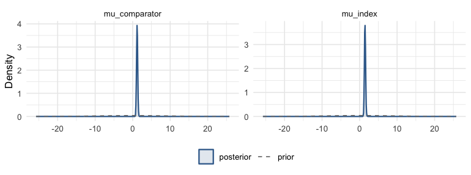

```r
plot_prior_posterior(fit_spfa, pars = c("mu_index", "mu_comparator"))
```

### Handling quasi-complete separation

With small or sparse binary data, rare events, or a covariate that almost perfectly predicts the outcome, the maximum-likelihood logistic fit can diverge (*quasi-complete separation*), and a flat or very wide prior lets the posterior chase it to implausibly large coefficients. A proper, substantively calibrated coefficient prior regularizes separated directions. Gelman et al. (2008) propose a Cauchy prior after a particular predictor scaling; a moderate Student-t is often easier to sample, but neither family makes 2.5 universally appropriate. No separate model is needed: the same `prior_beta` argument accepts a Student-t (or Cauchy) prior:

```r
# Student-t coefficients (df 3-7 is a robust default), autoscaled as above:
fit_sep <- mlumr(dat, model = "spfa",
                 prior_beta = prior_student_t(df = 5, 0, 2.5, autoscale = TRUE))
# prior_cauchy(0, 2.5) is the df = 1 special case (heaviest tails).
```

Use prior-predictive checks to set plausible scales and `prior_sensitivity()` to report how the result changes across the scales examined.

### Convergence

`mlumr()` warns automatically about divergences, treedepth saturation, high $\hat R$, and low effective sample size. They are clean here:

```r
data.frame(
  n_divergent  = fit_spfa$diagnostics$n_divergent,
  max_treedepth = fit_spfa$diagnostics$n_max_treedepth,
  max_Rhat     = round(max(fit_spfa$summary$Rhat, na.rm = TRUE), 3),
  min_ESS      = round(min(fit_spfa$summary$n_eff, na.rm = TRUE))
)
```

```
#>   n_divergent max_treedepth max_Rhat min_ESS
#> 1           0             0    1.004    1546
```

## Treatment effects

`marginal_effects()` reports three population-standardized binary effect measures in each population: the **log odds ratio** (`LOR`), the **risk difference** (`RD`), and the **risk ratio** (`RR`). Because ML-UMR targets *both* populations, you get a population-specific effect for each.

```r
me_spfa <- marginal_effects(fit_spfa, effect = "all")
knitr::kable(me_spfa, caption = "SPFA population-standardized effects (IXE_Q4W vs SEC_300)")
```

SPFA population-standardized effects (IXE_Q4W vs SEC_300)

| variable | effect | population | mean | sd | q2.5 | q50 | q97.5 |
| --- | --- | --- | --- | --- | --- | --- | --- |
| lor_index | LOR | Index | 0.2463067 | 0.2043813 | -0.1612142 | 0.2495905 | 0.6518974 |
| lor_comparator | LOR | Comparator | 0.2472410 | 0.2052714 | -0.1614905 | 0.2503917 | 0.6557578 |
| rd_index | RD | Index | 0.0462627 | 0.0386350 | -0.0294433 | 0.0465180 | 0.1231594 |
| rd_comparator | RD | Comparator | 0.0404362 | 0.0336325 | -0.0266875 | 0.0409191 | 0.1069070 |
| rr_index | RR | Index | 1.0656252 | 0.0561549 | 0.9623604 | 1.0637364 | 1.1814243 |
| rr_comparator | RR | Comparator | 1.0535080 | 0.0451545 | 0.9667412 | 1.0530110 | 1.1460981 |

A forest plot makes the value of adjustment visible, on the **log odds ratio**. ML-UMR is shown in **both** target populations. The **index population** is normally the decision-relevant one for HTA, since cost-effectiveness models are built for the population a reimbursement decision is about, which is usually the index trial’s (Chandler and Ishak 2026). STC is standardized to the comparator population; the naive contrast is not standardized to either population. Showing the comparator ML-UMR row provides the like-for-like STC comparison.

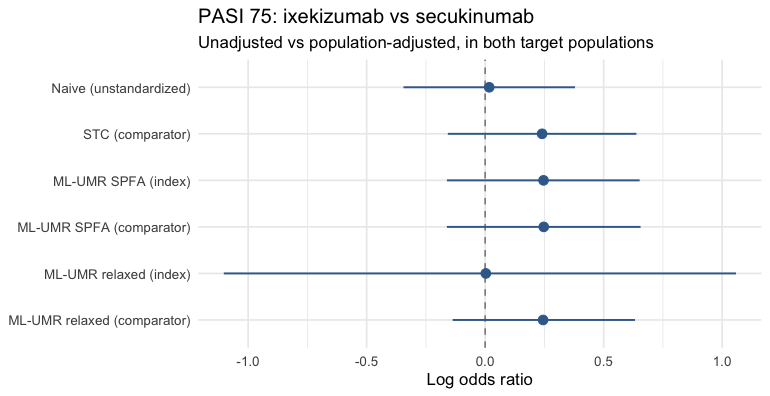

```r
me_spfa_b <- marginal_effects(fit_spfa, effect = "lor", population = "both")
me_rel_b  <- marginal_effects(fit_relaxed, effect = "lor", population = "both")
# One row per (model, population); `pop()` pulls the requested one.
pop <- function(d, which) d[d$population == which, ]
forest_df <- data.frame(
  label = c("Naive (unstandardized)", "STC (comparator)",
            "ML-UMR SPFA (index)", "ML-UMR SPFA (comparator)",
            "ML-UMR relaxed (index)", "ML-UMR relaxed (comparator)"),
  est = c(res_naive$link_effect, res_stc$link_effect,
          pop(me_spfa_b, "Index")$mean, pop(me_spfa_b, "Comparator")$mean,
          pop(me_rel_b, "Index")$mean, pop(me_rel_b, "Comparator")$mean),
  lo  = c(res_naive$ci_lower, res_stc$ci_lower,
          pop(me_spfa_b, "Index")$q2.5, pop(me_spfa_b, "Comparator")$q2.5,
          pop(me_rel_b, "Index")$q2.5, pop(me_rel_b, "Comparator")$q2.5),
  hi  = c(res_naive$ci_upper, res_stc$ci_upper,
          pop(me_spfa_b, "Index")$q97.5, pop(me_spfa_b, "Comparator")$q97.5,
          pop(me_rel_b, "Index")$q97.5, pop(me_rel_b, "Comparator")$q97.5)
)
mlumr_forest(forest_df, ref_line = 0,
             x = "Log odds ratio",
             title = "PASI 75: ixekizumab vs secukinumab",
             subtitle = "Unadjusted vs population-adjusted, in both target populations")
```

The full set of standardized effects in both populations, as a table:

```r
knitr::kable(marginal_effects(fit_relaxed, effect = "all", population = "both"),
   caption = "Relaxed-model standardized effects, both populations")
```

Relaxed-model standardized effects, both populations

| variable | effect | population | mean | sd | q2.5 | q50 | q97.5 |
| --- | --- | --- | --- | --- | --- | --- | --- |
| lor_index | LOR | Index | 0.0028398 | 0.5849539 | -1.1027831 | 0.0207378 | 1.0585269 |
| lor_comparator | LOR | Comparator | 0.2444256 | 0.1994718 | -0.1371652 | 0.2421185 | 0.6322585 |
| rd_index | RD | Index | 0.0144135 | 0.1020933 | -0.1437769 | 0.0035884 | 0.2314025 |
| rd_comparator | RD | Comparator | 0.0400623 | 0.0326564 | -0.0234464 | 0.0398917 | 0.1027967 |
| rr_index | RR | Index | 1.0388531 | 0.1558008 | 0.8393618 | 1.0046632 | 1.4242271 |
| rr_comparator | RR | Comparator | 1.0529897 | 0.0437571 | 0.9703815 | 1.0518831 | 1.1403727 |

The population-standardized log odds ratios, in both populations, plot straight from `marginal_effects()` with its `plot()` method (point estimate and 95% credible interval, faceted by measure):

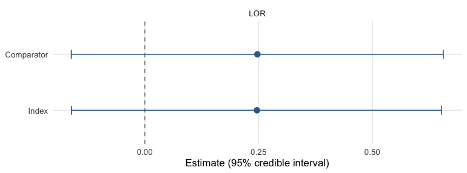

```r
plot(marginal_effects(fit_spfa, effect = "lor"))
```

## Absolute predictions

Absolute predicted response probabilities for each treatment in each population, as a table and as a plot. `plot()` on a `predict()` result draws the point-intervals directly, with the two populations distinguished by color:

```r
knitr::kable(predict(fit_spfa, population = "both", type = "response"),
   caption = "Standardized PASI 75 response probabilities")
```

Standardized PASI 75 response probabilities

| treatment | population | mean | sd | q2.5 | q50 | q97.5 |
| --- | --- | --- | --- | --- | --- | --- |
| IXE_Q4W | Index | 0.7742054 | 0.0215267 | 0.7311367 | 0.7744590 | 0.8156391 |
| SEC_300 | Index | 0.7279427 | 0.0317215 | 0.6626771 | 0.7288011 | 0.7869427 |
| IXE_Q4W | Comparator | 0.8110121 | 0.0230334 | 0.7637451 | 0.8119185 | 0.8531067 |
| SEC_300 | Comparator | 0.7705759 | 0.0235685 | 0.7221162 | 0.7712480 | 0.8138316 |

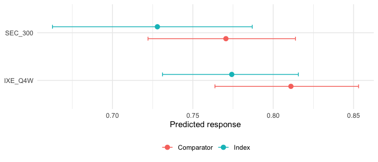

```r
plot(predict(fit_spfa, population = "both", type = "response"))
```

## Conditional effects

Conditional effects evaluate the contrast at specific covariate profiles rather than averaging over a population, useful for checking whether the effect is plausibly constant across the prognostic range (the SPFA assumption) or varies with the covariates:

```r
# Weight stays in kilograms in this vignette (IPD mean about 94), unlike
# `vignette("choosing-a-method")`, which divides it by 10. Profiles must be on
# the scale the model was fitted on, or the contrast is evaluated outside the
# covariate support.
profiles <- data.frame(age = c(40, 55, 70), bsa = c(0.15, 0.30, 0.45),
                       weight = c(75, 90, 110), prevsys = c(0, 1, 1))
knitr::kable(conditional_effects(fit_spfa, newdata = profiles),
   caption = "Conditional log odds ratios at three covariate profiles")
```

Conditional log odds ratios at three covariate profiles

| profile | effect | mean | sd | q2.5 | q50 | q97.5 |
| --- | --- | --- | --- | --- | --- | --- |
| 1 | LINK_EFFECT | 0.2666779 | 0.2222286 | -0.1697892 | 0.2697886 | 0.7096585 |
| 1 | RD | 0.0360436 | 0.0308723 | -0.0236670 | 0.0355675 | 0.1003421 |
| 1 | RR | 1.0454193 | 0.0401692 | 0.9714840 | 1.0431503 | 1.1330295 |
| 2 | LINK_EFFECT | 0.2666779 | 0.2222286 | -0.1697892 | 0.2697886 | 0.7096585 |
| 2 | RD | 0.0545626 | 0.0458718 | -0.0336336 | 0.0541125 | 0.1460648 |
| 2 | RR | 1.0831630 | 0.0727151 | 0.9548934 | 1.0782510 | 1.2388811 |
| 3 | LINK_EFFECT | 0.2666779 | 0.2222286 | -0.1697892 | 0.2697886 | 0.7096585 |
| 3 | RD | 0.0646590 | 0.0537742 | -0.0413750 | 0.0653554 | 0.1729787 |
| 3 | RR | 1.1526318 | 0.1400779 | 0.9261354 | 1.1364555 | 1.4762950 |

## Model comparison

Compare SPFA against the relaxed model with leave-one-out cross-validation and DIC. A markedly better relaxed fit would *suggest* effect modification, but the comparator coefficients are weakly identified from a single AgD row, so treat it as suggestive and check `prior_sensitivity()` (see `vignette("fitting-and-diagnostics")`).

```r
compare_models(SPFA = fit_spfa, Relaxed = fit_relaxed, criterion = "loo")
```

```
#>
#> Model Comparison (LOO)
#> ======================
#>
#>    model elpd_diff se_diff p_worse       diag_diff      diag_elpd
#>  Relaxed       0.0     0.0      NA                 1 k_psis > 0.7
#>     SPFA      -0.2     0.1    0.97 |elpd_diff| < 4 1 k_psis > 0.7
#>
#> elpd_diff is the difference in expected log pointwise predictive
#> density vs the best model, and se_diff is its standard error: the
#> uncertainty about that difference, not evidence for it. Read the two
#> together. A difference small relative to se_diff is not distinguished
#> from zero by this comparison, whatever se_diff itself is.
#> Treat any ratio as a heuristic, not a decision rule, and check the
#> PSIS diagnostics and whether the difference matters for the
#> prediction you care about.
```

```r
compare_models(SPFA = fit_spfa, Relaxed = fit_relaxed, criterion = "dic")
```

```
#>
#> Model Comparison (DIC)
#> ======================
#>
#>    Model    DIC   pD Delta_DIC
#>  Relaxed 367.87 5.71      0.00
#>     SPFA 368.60 6.22      0.73
#>
#> Lower DIC = better fit. Delta_DIC > 5 is a rough heuristic for
#> meaningful difference, not a formally calibrated threshold.
#> DIC should not be the sole basis for model selection.
```

## Interpretation

- The **naive** log odds ratio mixes the treatment contrast with between-study differences, including prognostic-factor imbalance.
- In this example **STC** and **ML-UMR SPFA** both standardize over the named covariates and broadly agree. ML-UMR reports posterior uncertainty and effects in *both* populations, which matters when the decision population is not the comparator’s.
- The **relaxed** model relaxes the shared-effect assumption but pays for it in precision here, because the comparator-specific coefficients lean on one aggregate row. Its comparator-population estimate stays close to SPFA, but its index-population estimate falls back to about the naive value, with an interval more than two log odds ratios wide (see the both-populations table above). The index-population estimand extrapolates comparator coefficients that a single aggregate row cannot identify, so read that divergence as a statement about identification, not about effect modification.

> **Data provenance.** `psoriasis_ipd` / `psoriasis_agd` are bundled with mlumr, copied verbatim from the GPL-3 `multinma` package (Phillippo 2024) (`plaque_psoriasis_ipd` / `plaque_psoriasis_agd`), which provides simulated IPD resembling the UNCOVER-2 (Griffiths et al. 2015) and FIXTURE (Langley et al. 2014) trials. This unanchored two-study framing is for illustration; the trials were not designed for a head-to-head indirect comparison.

## References

Chandler, C., and K. J. Ishak. 2025. *Anchors Away: Navigating Unanchored Indirect Comparisons with Multilevel Unanchored Meta-Regression*. ISPOR Europe, Glasgow, UK; abstract MSR28. https://www.valueinhealthjournal.com/article/S1098-3015(25)05944-3/abstract.

Chandler, Conor, and K. Jack Ishak. 2026. *Reframing Population-Adjusted Indirect Comparisons as a Transportability Problem: An Estimand-Based Perspective and Implications for Health Technology Assessment*. Preprint. https://doi.org/10.48550/arXiv.2602.17041.

Gelman, Andrew, Aleks Jakulin, Maria Grazia Pittau, and Yu-Sung Su. 2008. “A Weakly Informative Default Prior Distribution for Logistic and Other Regression Models.” *The Annals of Applied Statistics* 2 (4): 1360–83. https://doi.org/10.1214/08-AOAS191.

Griffiths, C. E. M., K. Reich, M. Lebwohl, et al. 2015. “Comparison of Ixekizumab with Etanercept or Placebo in Moderate-to-Severe Psoriasis (UNCOVER-2 and UNCOVER-3): Results from Two Phase 3 Randomised Trials.” *The Lancet* 386 (9993): 541–51. https://doi.org/10.1016/s0140-6736(15)60125-8.

Langley, R. G., B. E. Elewski, M. Lebwohl, et al. 2014. “Secukinumab in Plaque Psoriasis — Results of Two Phase 3 Trials.” *New England Journal of Medicine* 371 (4): 326–38. https://doi.org/10.1056/nejmoa1314258.

Phillippo, D. M., S. Dias, A. E. Ades, et al. 2020. “Multilevel Network Meta-Regression for Population-Adjusted Treatment Comparisons.” *Journal of the Royal Statistical Society: Series A (Statistics in Society)* 183 (3): 1189–210. https://doi.org/10.1111/rssa.12579.

Phillippo, David M. 2024. *multinma: Bayesian Network Meta-Analysis of Individual and Aggregate Data*. https://doi.org/10.5281/zenodo.3904454.